# EasyVisa_Full_Code_Rahman

### Now using Ada boost

```python
adaboost = AdaBoostClassifier(random_state=1)
adaboost.fit(X_train,y_train)
```

```
AdaBoostClassifier(random_state=1)
```

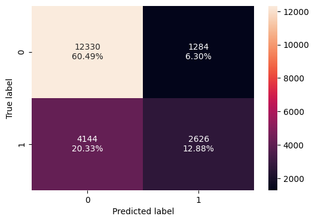

```python
#Using above defined function to get accuracy, recall and precision on train and test set
confusion_matrix_sklearn(adaboost, X_train, y_train)
```

```python
adaboost_train_perf = model_performance_classification_sklearn(
    adaboost, X_train, y_train
)
adaboost_train_perf
```

|  | Accuracy | Recall | Precision | F1 |
| --- | --- | --- | --- | --- |
| 0 | 0.733713 | 0.387888 | 0.671611 | 0.49176 |

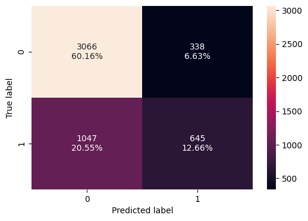

```python
#Using above defined function to get accuracy, recall and precision on train and test set
confusion_matrix_sklearn(adaboost, X_test, y_test)
```

```python
adaboost_test_perf = model_performance_classification_sklearn(
    adaboost, X_test, y_test
)
adaboost_test_perf
```

|  | Accuracy | Recall | Precision | F1 |
| --- | --- | --- | --- | --- |
| 0 | 0.728218 | 0.381206 | 0.656155 | 0.482243 |

- Compare to others so far the train and test is almost similar. There is a slight difference between the training and test F1 Scores.This indicates that the model is slightly overfitting.
- Not hypertuning this intentionally now as the best three models will be hypertuned later in the section. Hence we will now consider Gradient Boost

### Now using Gradient Boosting Classifier

```python
gboost = GradientBoostingClassifier(random_state=1)
gboost.fit(X_train,y_train)
```

```
GradientBoostingClassifier(random_state=1)
```

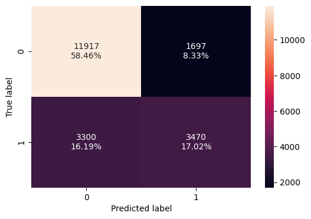

```python
#Using above defined function to get accuracy, recall and precision on train and test set
confusion_matrix_sklearn(gboost, X_train, y_train)
```

```python
gboost_train_perf = model_performance_classification_sklearn(
    gboost, X_train, y_train
)
gboost_train_perf
```

|  | Accuracy | Recall | Precision | F1 |
| --- | --- | --- | --- | --- |
| 0 | 0.754857 | 0.512555 | 0.67157 | 0.581386 |

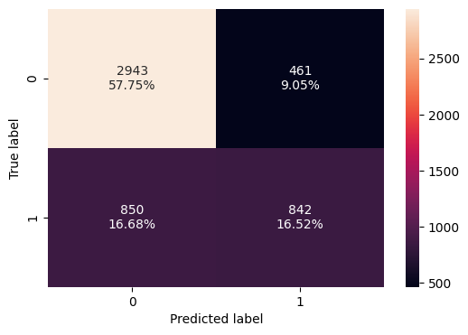

```python
#Using above defined function to get accuracy, recall and precision on train and test set
confusion_matrix_sklearn(gboost, X_test, y_test)
```

```python
gboost_test_perf = model_performance_classification_sklearn(
    gboost, X_test, y_test
)
gboost_test_perf
```

|  | Accuracy | Recall | Precision | F1 |
| --- | --- | --- | --- | --- |
| 0 | 0.742739 | 0.497636 | 0.646201 | 0.56227 |

- As with AdaBoosting there is a slight difference between the training and test F1 Scores.This indicates that the model is slightly overfitting.
- Not hypertuning this intentionally now as the best three models will be hypertuned later in the section. Hence we will now consider XG Boost

### Now using XGBoost Classifier

```python
xgboost = XGBClassifier(random_state=1,eval_metric='logloss')
xgboost.fit(X_train, y_train)
```

```
XGBClassifier(base_score=None, booster=None, callbacks=None,
              colsample_bylevel=None, colsample_bynode=None,
              colsample_bytree=None, device=None, early_stopping_rounds=None,
              enable_categorical=False, eval_metric='logloss',
              feature_types=None, gamma=None, grow_policy=None,
              importance_type=None, interaction_constraints=None,
              learning_rate=None, max_bin=None, max_cat_threshold=None,
              max_cat_to_onehot=None, max_delta_step=None, max_depth=None,
              max_leaves=None, min_child_weight=None, missing=nan,
              monotone_constraints=None, multi_strategy=None, n_estimators=None,
              n_jobs=None, num_parallel_tree=None, random_state=1, ...)
```

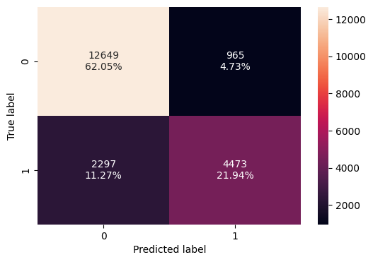

```python
#Using above defined function to get accuracy, recall and precision on train and test set
confusion_matrix_sklearn(xgboost, X_train, y_train)
```

```python
xgboost_train_perf = model_performance_classification_sklearn(
    xgboost, X_train, y_train
)
xgboost_train_perf
```

|  | Accuracy | Recall | Precision | F1 |
| --- | --- | --- | --- | --- |
| 0 | 0.839973 | 0.660709 | 0.822545 | 0.732798 |

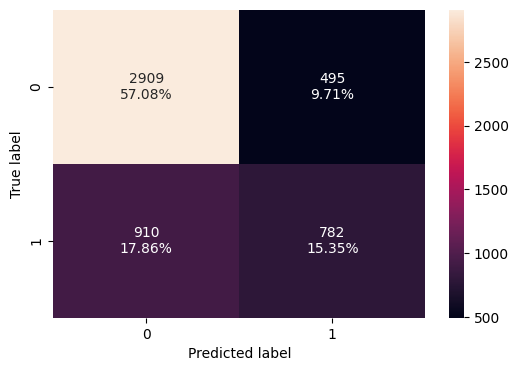

```python
#Using above defined function to get accuracy, recall and precision on train and test set
confusion_matrix_sklearn(xgboost, X_test, y_test)
```

```python
xgboost_test_perf = model_performance_classification_sklearn(
    xgboost, X_test, y_test
)
xgboost_test_perf
```

|  | Accuracy | Recall | Precision | F1 |
| --- | --- | --- | --- | --- |
| 0 | 0.724294 | 0.462175 | 0.612373 | 0.526777 |

- Compared to AdaBoosting and Gradient Boosting there is a more difference between the training and test F1 Scores in XGBoost.This indicates that the model is more overfitting when compared to Ada and Gradient boosting.
- Not hypertuning this intentionally now as the best three models will be hypertuned later in the section.

#### Defining scorer to be used for cross-validation and hyperparameter tuning

### Model Building with oversampled data

#### Before we under or over sample the data, let us split the data into train, test and validation

```python
# Splitting data into training, validation and test set:

# first we split data into 2 parts, say temporary and test
X_train, X_temp, y_train, y_temp = train_test_split(
    X, y, test_size=0.5, random_state=0, stratify=y
)

# then we split the temporary set into train and validation
X_val, X_test, y_val, y_test = train_test_split(
    X_temp, y_temp, test_size=0.4, random_state=0, stratify=y_temp
)

print(X_train.shape, X_val.shape, X_test.shape)
```

```
(12740, 16) (7644, 16) (5096, 16)
```

```python
# Checking class balance for whole data, train set, validation set, and test set

print("Target value ratio in y")
print(y.value_counts(1))
print("*" * 80)
print("Target value ratio in y_train")
print(y_train.value_counts(1))
print("*" * 80)
print("Target value ratio in y_val")
print(y_val.value_counts(1))
print("*" * 80)
print("Target value ratio in y_test")
print(y_test.value_counts(1))
print("*" * 80)
```

```
Target value ratio in y
case_status
0    0.667896
1    0.332104
Name: proportion, dtype: float64
Target value ratio in y_train
case_status
0    0.667896
1    0.332104
Name: proportion, dtype: float64
Target value ratio in y_val
case_status
0    0.667844
1    0.332156
Name: proportion, dtype: float64
Target value ratio in y_test
case_status
0    0.667975
1    0.332025
Name: proportion, dtype: float64
```

- Oversampling the data using SMOTE

```python
# Fit SMOTE on train data(Synthetic Minority Oversampling Technique)
sm = SMOTE(sampling_strategy='auto', k_neighbors=5, random_state=1)
X_train_over, y_train_over = sm.fit_resample(X_train, y_train)
```

```python
print("Before OverSampling, count of label '1': {}".format(sum(y_train == 1)))
print("Before OverSampling, count of label '0': {} \n".format(sum(y_train == 0)))

print("After OverSampling, count of label '1': {}".format(sum(y_train_over == 1)))
print("After OverSampling, count of label '0': {} \n".format(sum(y_train_over == 0)))

print("After OverSampling, the shape of train_X: {}".format(X_train_over.shape))
print("After OverSampling, the shape of train_y: {} \n".format(y_train_over.shape))
```

```
Before OverSampling, count of label '1': 4231
Before OverSampling, count of label '0': 8509

After OverSampling, count of label '1': 8509
After OverSampling, count of label '0': 8509

After OverSampling, the shape of train_X: (17018, 16)
After OverSampling, the shape of train_y: (17018,)
```

- Using thre pre-puned Decision Tree for oversampled data

```python
# training the decision tree model with oversampled training set
dtree2.fit(X_train_over, y_train_over)
```

```
DecisionTreeClassifier(max_depth=np.int64(8), max_leaf_nodes=np.int64(10),
                       min_samples_split=np.int64(10), random_state=42)
```